# Анализ социальной структуры группы Вконтакте ‘Подслушано в тюрьме’

*Описание работы*

Для своей работы мы скачали данные публичной группы ВКонтакте “Подслушано в тюрьме”, где общаются люди, находящиеся в местах заключения между собой и с людьми, находящимися “на свободе”, желающие познакомиться или поддержать контакт с заключенными в МЛС.

Идея заключается в том, чтобы посмотреть на то, какова структура сети данной группы. Является ли она плотной или нет? Каковы самые высокие показатели мер центральности? Мы постараемся в максимально развернутой форме ответить на вопросы, предложенные в задании.

Стоит отметить, что мы оставляем исключительно реципрокные связи, чтобы определить друзей, которые дабавили друг друга в друзья и исключить “фолловеров” (однонаправленная связь). Тем самым мы также снижаем размерность сети - на полная база данных содержит информацию об около 34 тысячах связей.

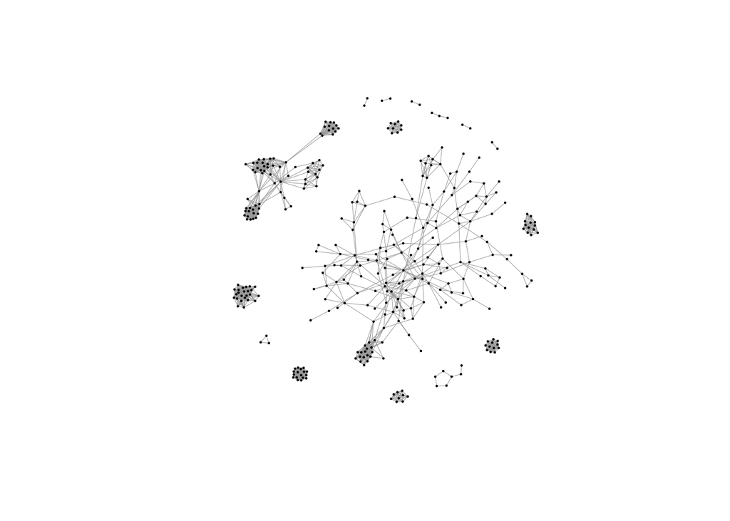

# Меры центральности

Для начала создадим базу данных со всеми мерами центральости, которые будут использоваться далее.

## Degree centrality

Для начала выявим, кто в сети подписчиков важнее по признаку “у кого больше друзей” (чем больше связей, тем лучше). Такой показатель называется **степенью (degree)**.

(Помним, что в данный момент наши данные содержат узлы с дегри предварительно отфильтрованы)

```
##   Degree  n
## 1      1 36
## 2      2 41
## 3      3 35
## 4      4 31
## 5      5 22
## 6      6 14
```

```
##    Degree  n
## 16     16 21
## 17     17  8
## 18     18 10
## 19     19  4
## 20     20  2
## 21     23  1
```

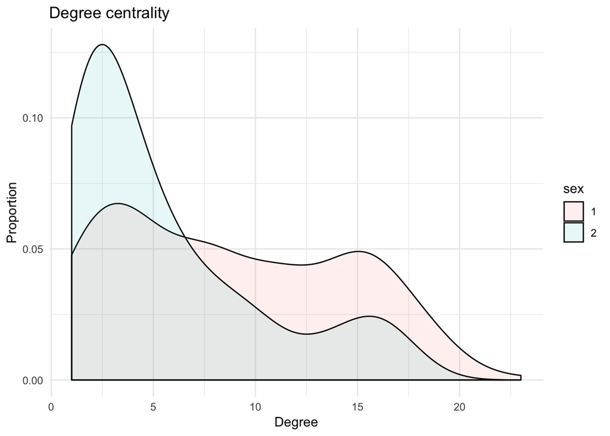

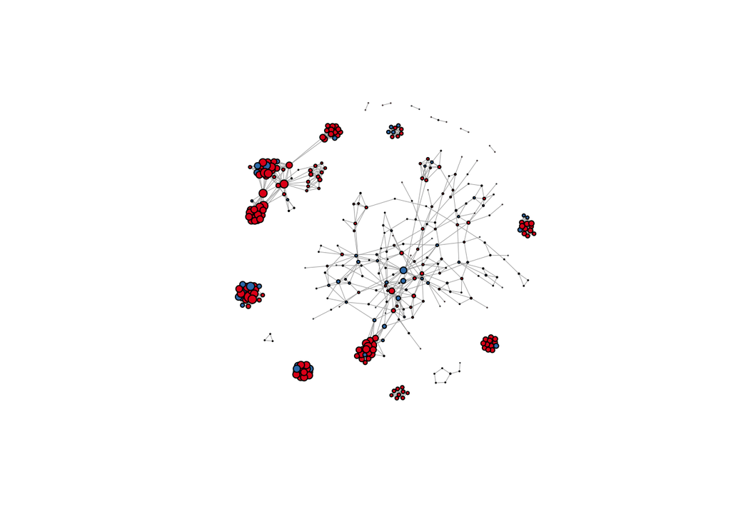

## Closeness centrality

Если нам интересны вершины с наиболее короткими путями до остальных (т.е. наиболее близкие к остальным), то рассматривается **центральность по близости (closeness)**.

```
##        Closeness  n
## 1 0.000007802503 10
## 2 0.000007824298  2
## 3 0.000007824359  4
## 4 0.000007912331  1
## 5 0.000007912582  2
## 6 0.000007912644  1
```

```
##         Closeness n
## 203 0.00001540903 2
## 204 0.00001541283 1
## 205 0.00001541402 1
## 206 0.00001541497 1
## 207 0.00001541640 1
## 208 0.00001542044 1
```

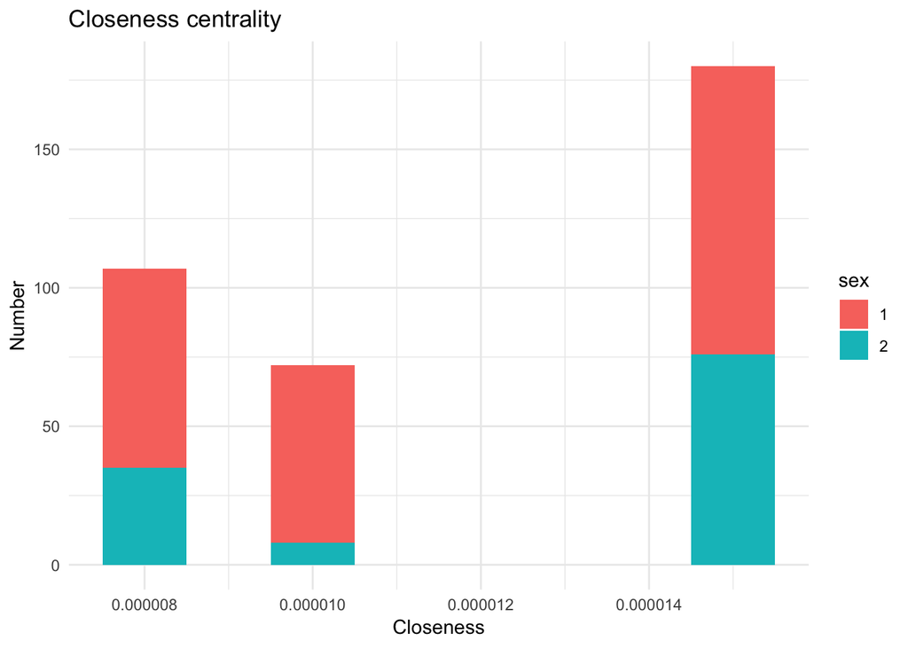

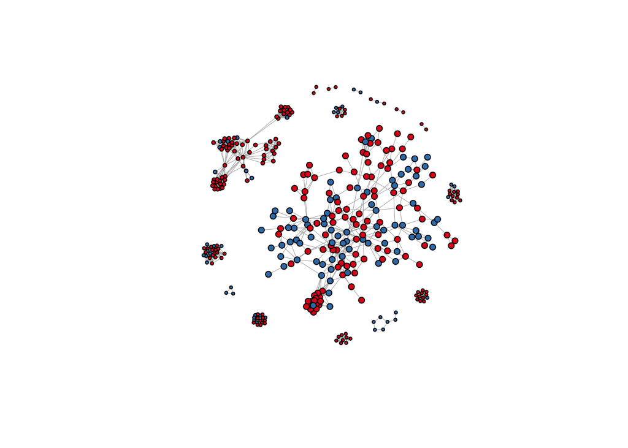

```
##        Min.     1st Qu.      Median        Mean     3rd Qu.        Max.
## 0.000007803 0.000008313 0.000015232 0.000012045 0.000015357 0.000015420
```

## Betweenness centrality

Еще одним рассматриваемым показателем является **центральность по посредничеству, битвинность (betweenness)**. В этом случае важны вершины, которые являются посредниками между группами, находятся на “выгодном” месте.

### Node Betweenness

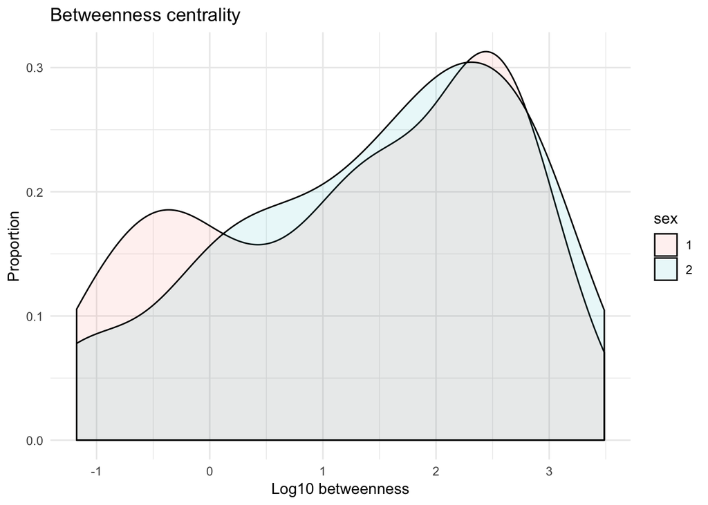

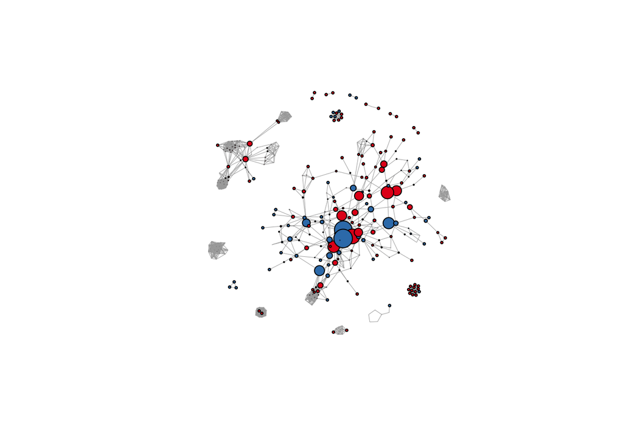

```
##      Min.   1st Qu.    Median      Mean   3rd Qu.      Max.
##    0.0000    0.0667    7.7472  184.1560  178.1930 3067.2458
```

### Edge Betweenness

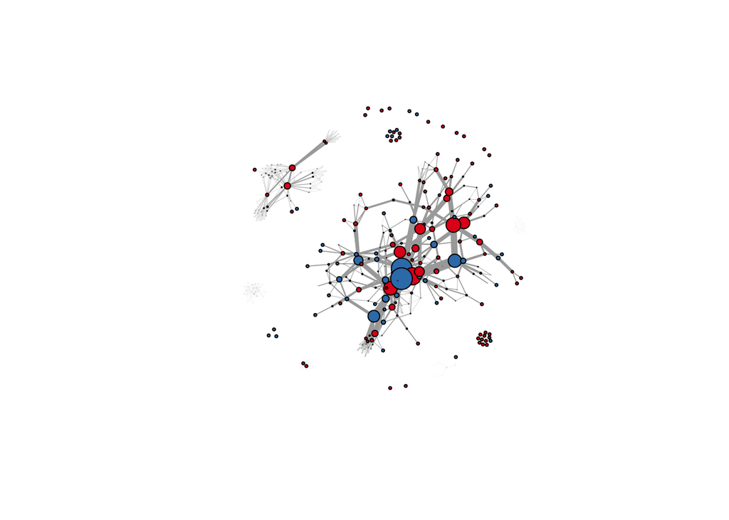

```
##     Min.  1st Qu.   Median     Mean  3rd Qu.     Max.
##    1.000    1.143    3.541   61.733   39.433 1663.341
```

## Information centrality

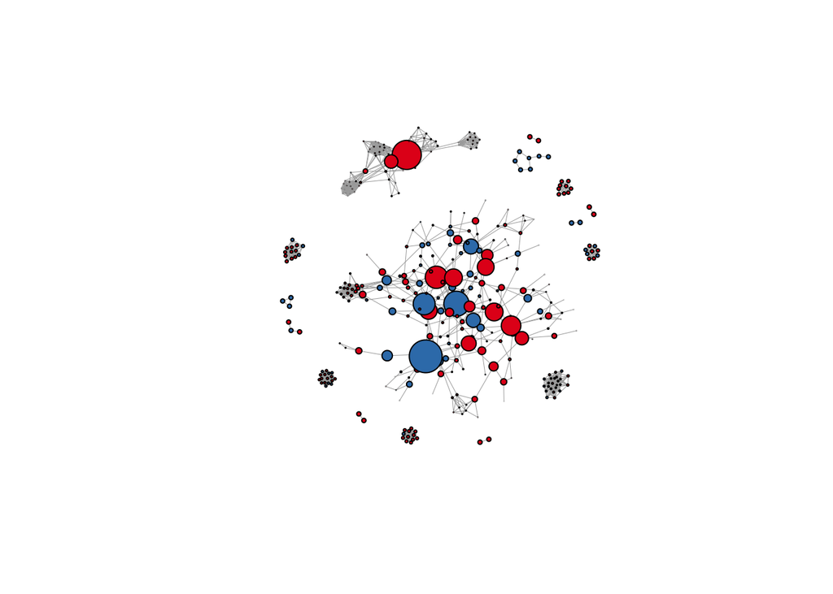

```
## + 24/359 vertices, named, from dddc72d:
##  [1] 294084542 440771887 298093135 385327789 119575815 446864942 67091199
##  [8] 13176725  499445780 306905399 358294272 259899780 295685011 71746190
## [15] 367310486 279920759 220806129 325524539 294371282 361032038 273401983
## [22] 382765513 321597693 298361053
```

```
##       Min.    1st Qu.     Median       Mean    3rd Qu.       Max.
## -0.0054280 -0.0024661  0.0005193  0.0017273  0.0032017  0.0417062
```

```
##       Min.    1st Qu.     Median       Mean    3rd Qu.       Max.
## -0.0054280 -0.0024661  0.0005193  0.0017273  0.0032017  0.0417062
```

# Меры централизации

## Degree Centralization

Метрика для сети и для идеальной сети:

```
## [1] 0.04270864
```

```
## [1] 128522
```

## Information Centralization

Метрика для сети:

```
## [1] 14.35242
```

## Closeness Centralization

Метрика для сети и для идеальной сети:

```
## [1] 0.002427103
```

```
## [1] 178.7497
```

## Betweenness Centralization

Метрика для сети и для идеальной сети:

```
## [1] 0.04524268
```

```
## [1] 22877274
```

## Edge betweenness Centralization

Метрика для сети:

```
## [1] 2216626
```

# Eigenvector Centrality

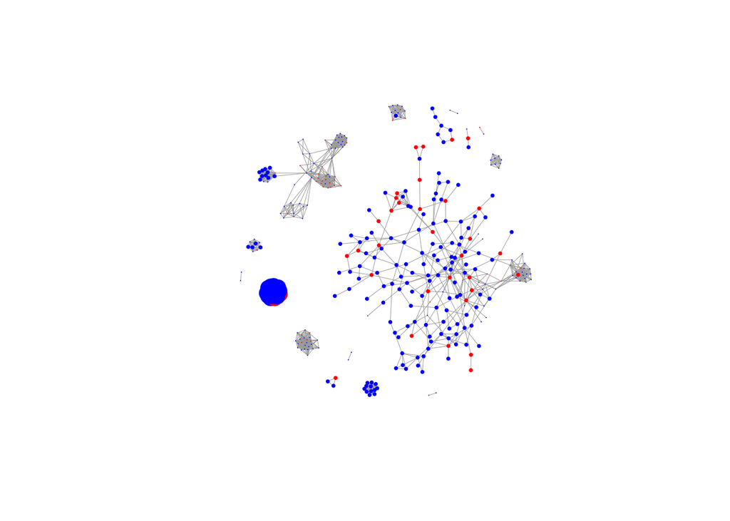

```
##    Min. 1st Qu.  Median    Mean 3rd Qu.    Max.
## 0.00000 0.00000 0.00000 0.04704 0.00000 1.00000
```

# Атрибуты и их распределение в завимости от мер центральности

## Гомофилия по возрастным группам

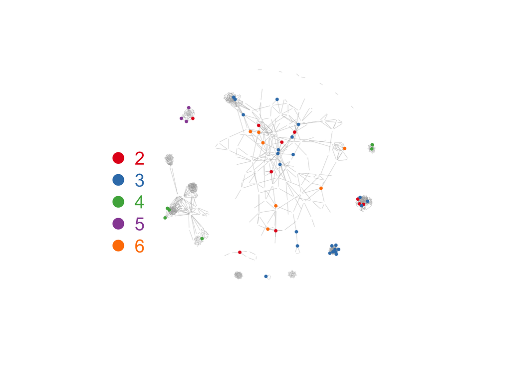

## Гомофилия по гендеру

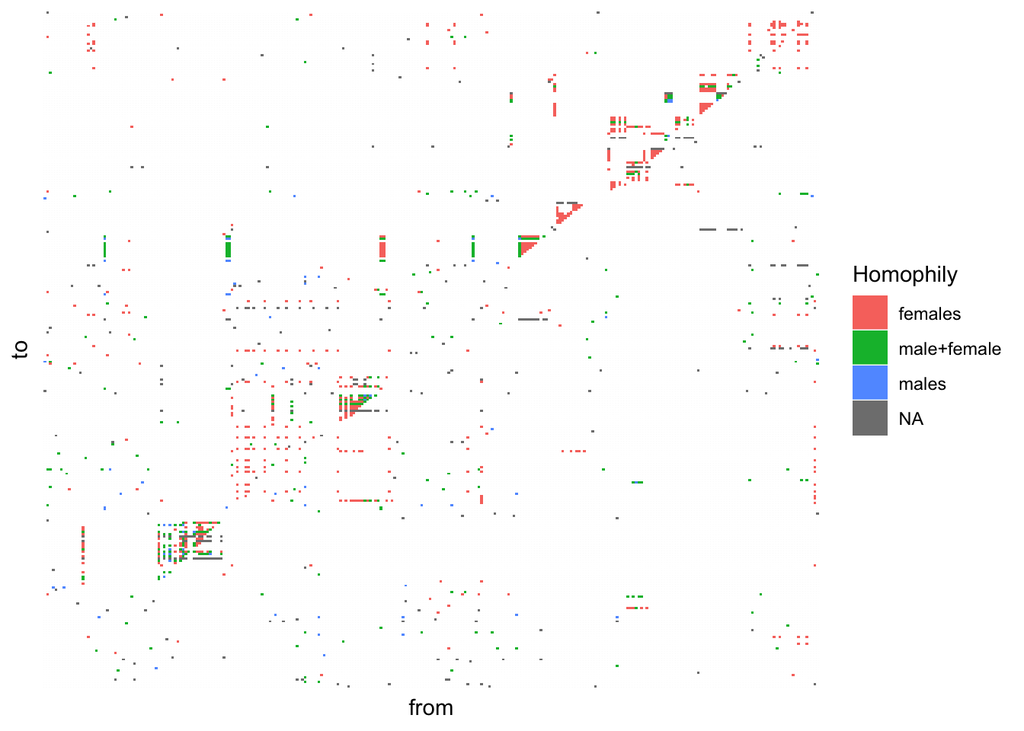